# Econ History Assignment 2

Ali BENRAMDANE, Mathilde BLANCHON, Jonathan GARSON, Andrea MAESTRI

Nov 29, 2024

# Econ History Assignment 2

## Loading libraries

```r
library(data.table)
library(fixest)
library(stargazer)
library(aod)
library(readxl)
library(countrycode)
library(pROC)
library(lpirfs)
library(tidyverse)
library(ggplot2)
```

## Importing data

```r
jst = fread("../data/JSTdatasetR6.csv")
rec = fread("../data/RecessionDummies.csv")
bvx = fread("../data/bvx_crises_list.csv")
```

## Part A - Logit

Estimate a logit model with country fixed effects and with five lags of log changes in Real Credit as a predictor for JST crises and document the results in table.

- Test for joint significance of five lags credit growth.
- Repeat with BVX crisis date
- Use 5-year change in the ratio of credit over GDP predictor

#### JST Crises

```r
# Create dependent variable (real credit log-change)
jst[, tloans_real := tloans/cpi]
jst[, ln_tloans_real := log(tloans_real),]
jst[, ln_diff_tloans := ln_tloans_real - shift(ln_tloans_real, 1, type = "lag"), by = country]

#Estimate logit model
logit_credit = glm(crisisJST ~
    shift(ln_diff_tloans, 1, type = "lag")
    + shift(ln_diff_tloans, 2, type = "lag")
    + shift(ln_diff_tloans, 3, type = "lag")
    + shift(ln_diff_tloans, 4, type = "lag")
    + shift(ln_diff_tloans, 5, type = "lag")
    + factor(country)
  ,family = binomial(link = "logit"),
  data = jst)

#Print results
stargazer(logit_credit,
        type = "text",
        align = TRUE,
        omit = c("country"),
        dep.var.labels = c("Crisis (JST)"),
        covariate.labels = c("Log-change Real Credit - T-1",
                             "Log-change Real Credit - T-2",
                             "Log-change Real Credit - T-3",
                             "Log-change Real Credit - T-4",
                             "Log-change Real Credit - T-5"))
```

```
##
## ========================================================
##                                  Dependent variable:
##                              ---------------------------
##                                     Crisis (JST)
## --------------------------------------------------------
## Log-change Real Credit - T-1            0.367
##                                        (1.372)
##
## Log-change Real Credit - T-2          6.742***
##                                        (1.224)
##
## Log-change Real Credit - T-3           -0.474
##                                        (1.051)
##
## Log-change Real Credit - T-4            0.007
##                                        (0.978)
##
## Log-change Real Credit - T-5            1.151
##                                        (1.101)
##
## Constant                              -4.697***
##                                        (0.725)
##
## --------------------------------------------------------
## Observations                            2,333
## Log Likelihood                        -306.139
## Akaike Inf. Crit.                      658.278
## ========================================================
## Note:                        *p<0.1; **p<0.05; ***p<0.01
```

The findings indicate that the log-change in real credit at T-2 is the only statistically significant predictor of a crisis in this model. Its effect is positive: an increase in credit in period t increases the likelihood of witnessing a crisis in t+2. In contrast, the other lagged variables do not show significant contributions to explaining the likelihood of a crisis.

We now test for the joint significance of the lag variables. A first attempt to challenge the joint significance could be a Wald test. The null hypothesis is that the five lags of credit growth are not jointly significant:

$$\begin{aligned}
H_0: \beta_1 = \beta_2 = \beta_3 = \beta_4 = \beta_5 = 0\\
\end{aligned}$$

```r
#Perform Wald test
wald.test(
b = coef(logit_credit),  # Coefficients from the full model
Sigma = vcov(logit_credit),  # Variance-covariance matrix of coefficients
Terms = 2:6 # Indices of lagged predictors in the model
  )
```

```
## Wald test:
## ----------
##
## Chi-squared test:
## X2 = 35.8, df = 5, P(> X2) = 1e-06
```

Complementary, we can test joint significance with the likelihood ratio chi-square test. This tests consists of comparing the full model with a restricted model without the variables we want to test for. Let’s first estimate the restricted model.

```r
# Test for joint significance of five lags credit growth.
# We run a restricted model which excludes the five lags of credit growth
restricted_model <- glm(
  formula = crisisJST ~ factor(country),
  data = jst,
  family = binomial(link = "logit")
)
```

Now let’s run the LR test.

```r
lr_stat <- 2 * (logLik(logit_credit) - logLik(restricted_model))
df <- 5
p_value <- pchisq(lr_stat, df = df, lower.tail = FALSE)
cat("Likelihood Ratio Statistic:", lr_stat, "\n")
```

```
## Likelihood Ratio Statistic: 141.4017
```

```r
cat("Degrees of Freedom:", df, "\n")
```

```
## Degrees of Freedom: 5
```

```r
cat("P-value:", p_value, "\n")
```

```
## P-value: 9.009139e-29
```

In both cases the p-value is close to 0, which means that we can reject the null hypothesis. Therefore, the five lags jointly contribute significantly to predicting the crisis variable.

#### BVX Crises

```r
# Merge JST and BVX datasets
setnames(bvx, "countrycode", "iso")
bvx = bvx[, country := NULL]
jst = merge(jst, bvx, all.x = TRUE, by = c("iso", "year"))

# Estimate logit model for BVX crisis indicator
logit_bvx = glm(bvx_crisis ~
      shift(ln_diff_tloans, 1, type = "lag")
      + shift(ln_diff_tloans, 2, type = "lag")
      + shift(ln_diff_tloans, 3, type = "lag")
      + shift(ln_diff_tloans, 4, type = "lag")
      + shift(ln_diff_tloans, 5, type = "lag")
      + factor(country)
    ,family = binomial(link = "logit"),
    data = jst)

#Print the results
stargazer(logit_bvx,
          type = "text",
          align = TRUE,
          omit = c("country"),
          dep.var.labels = c("BVX Crisis"),
          covariate.labels = c("Log-change Real Credit - T-1",
                             "Log-change Real Credit - T-2",
                             "Log-change Real Credit - T-3",
                             "Log-change Real Credit - T-4",
                             "Log-change Real Credit - T-5"))
```

```
##
## ========================================================
##                                  Dependent variable:
##                              ---------------------------
##                                      BVX Crisis
## --------------------------------------------------------
## Log-change Real Credit - T-1           -0.476
##                                        (0.991)
##
## Log-change Real Credit - T-2          5.284***
##                                        (1.104)
##
## Log-change Real Credit - T-3           -0.786
##                                        (0.913)
##
## Log-change Real Credit - T-4           -0.046
##                                        (0.890)
##
## Log-change Real Credit - T-5           2.210**
##                                        (0.933)
##
## Constant                              -4.170***
##                                        (0.592)
##
## --------------------------------------------------------
## Observations                            2,334
## Log Likelihood                        -393.046
## Akaike Inf. Crit.                      832.092
## ========================================================
## Note:                        *p<0.1; **p<0.05; ***p<0.01
```

Similar to what was found with JST crisis, the outputs of the regression indicate that the log-change in real credit at T-2 is a statistically significant predictor of a crisis. Once again, its effect is positive: an increase in credit in period t increases the likelihood of witnessing a crisis in t+2. However, using BVX crisis we find that log change in real credit at T-5 is also a statistically significant predictor of a crisis. It’s effect is however weaker as the coefficient is lower.

Overall, the result serves well as a robustness check for the relationship previously uncovered between credit growth and financial crisis likelihood, as the result holds also using a different indicator for financial crises.

```r
# Perform Wald test
wald.test(
  b = coef(logit_bvx),  # Coefficients from the full model
  Sigma = vcov(logit_bvx),  # Variance-covariance matrix of coefficients
  Terms = 2:6 # Indices of lagged predictors in the model
)
```

```
## Wald test:
## ----------
##
## Chi-squared test:
## X2 = 30.1, df = 5, P(> X2) = 1.4e-05
```

Using the Wald test, we are able to reject the null hypothesis of independence, implying joint significance of the predictors. Hence, we get approximately the same result between BVX and JST crises classifications.

#### Credit-to-GDP Ratio

\

Used 5-year change in the ratio of credit over GDP as a predictor

```r
# Create dependent variable
jst[, `:=` (gdp_real = gdp/cpi), by = c("country")]
jst[, creditgdp := tloans_real/gdp_real, by = c("country")]
jst[, creditgdpchange := creditgdp - shift(creditgdp, 5, type = "lag")]

# Estimate model
logit_gdp = glm(crisisJST ~
                creditgdpchange
                + factor(country)
                ,family = binomial(link = "logit"),
                data = jst)

# Print results
stargazer(logit_gdp,
          type = "text",
          align = TRUE,
          omit = c("country"),
        dep.var.labels = c("Crisis (JST)"),
        covariate.labels = c("Credit-to-GDP 5Y Change"))
```

```
##
## ===================================================
##                             Dependent variable:
##                         ---------------------------
##                                Crisis (JST)
## ---------------------------------------------------
## Credit-to-GDP 5Y Change          3.413***
##                                   (0.866)
##
## Constant                         -4.483***
##                                   (0.718)
##
## ---------------------------------------------------
## Observations                       2,348
## Log Likelihood                   -318.110
## Akaike Inf. Crit.                 674.221
## ===================================================
## Note:                   *p<0.1; **p<0.05; ***p<0.01
```

Modeling the likelihood of a financial crisis through the 5-year change in the credit-to-GDP ratio, we yield a positive and significant coefficient. This is not surprising, as we had already rejected the hypothesis of independence between likelihood of a financial crisis and credit growth lags, and the coefficient might be absorbing the effect of the change in credit growth observed two years before the crisis.

### Model estimation

#### ROC test - Logit Model predictions using Real Credit Change

Compare in-sample and out of sample ROC, estimating the model until 1984 and predicting crisis for post-1984 years.

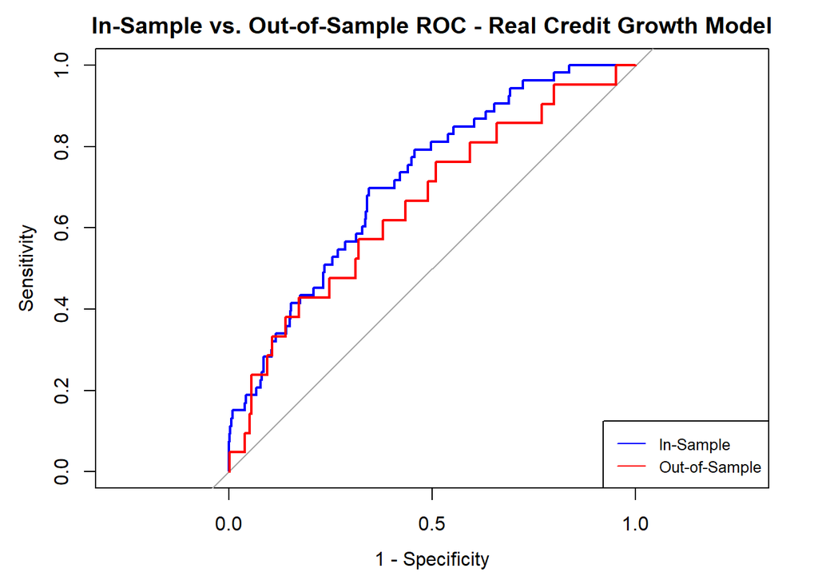

```r
# we split data in two
pre1984 = jst[year <= 1984,]
post1984 = jst[year > 1984,]

# we test on our pre-1984 data
logit_1984 = glm(crisisJST ~
      shift(ln_diff_tloans, 1, type = "lag")
      + shift(ln_diff_tloans, 2, type = "lag")
      + shift(ln_diff_tloans, 3, type = "lag")
      + shift(ln_diff_tloans, 4, type = "lag")
      + shift(ln_diff_tloans, 5, type = "lag")
      + country
    ,family = binomial(link = "logit"),
    data = pre1984)

# Predict probabilities for training data (in-sample)
pre1984$predicted_prob <- predict(logit_1984, pre1984, type = "response")

# Predict probabilities for testing data (out-of-sample)
post1984$predicted_prob <- predict(logit_1984, post1984, type = "response")

# Compute ROC curve for in-sample data
roc_in_sample <- roc(pre1984$crisisJST, pre1984$predicted_prob)
# Compute ROC curve for out-of-sample data
roc_out_sample <- roc(post1984$crisisJST, post1984$predicted_prob)
# Plot ROC curves
plot(roc_in_sample, col = "blue", main = "In-Sample vs. Out-of-Sample ROC - Real Credit Growth Model", legacy.axes = TRUE)
plot(roc_out_sample, col = "red", add = TRUE)

# Add legend
legend("bottomright", legend = c("In-Sample", "Out-of-Sample"),
       col = c("blue", "red"), lty = 1, cex = 0.8)
```

```r
# Print AUC values
cat("In-Sample AUC: ", auc(roc_in_sample), "\n")
```

```
## In-Sample AUC:  0.7161041
```

```r
cat("Out-of-Sample AUC: ", auc(roc_out_sample), "\n")
```

```
## Out-of-Sample AUC:  0.6581494
```

As we can judge from the Area Under the ROC (AUROC/AUC), the logit model using real credit as a predictor for financial crises has satisfactory in-sample performances (In-Sample AUC: 0.7161041), which drop slightly below the usual satisfactory threshold of 0.7 when predicting out of sample (Out-of-Sample AUC: 0.6581494). Further adjustments and variables might be needed to have a model with better predictive power.

#### Money as predictor

Compare the baseline model to a logit model with money as a predictor.

```r
# Create dependent variable
jst[, money_real := money/cpi]
jst[, ln_money_real := log(money_real),]
jst[, ln_diff_money_real := ln_money_real - shift(ln_money_real, 1, type = "lag"), by = country]

# Estimate model
logit_money = glm(crisisJST ~
      shift(ln_diff_money_real, 1, type = "lag")
      + shift(ln_diff_money_real, 2, type = "lag")
      + shift(ln_diff_money_real, 3, type = "lag")
      + shift(ln_diff_money_real, 4, type = "lag")
      + shift(ln_diff_money_real, 5, type = "lag")
      + factor(country)
    ,family = binomial(link = "logit"),
    data = jst)

#Print the results
stargazer(logit_money,
          type = "text",
          align = TRUE,
          omit = c("country"),
        dep.var.labels = c("Crisis (JST)"),
        covariate.labels = c("Log-change Money - T-1",
                             "Log-change Money - T-2",
                             "Log-change Money - T-3",
                             "Log-change Money - T-4",
                             "Log-change Money - T-5"))
```

```
##
## ==================================================
##                            Dependent variable:
##                        ---------------------------
##                               Crisis (JST)
## --------------------------------------------------
## Log-change Money - T-1            1.841
##                                  (1.728)
##
## Log-change Money - T-2           4.241**
##                                  (1.702)
##
## Log-change Money - T-3           -0.692
##                                  (1.623)
##
## Log-change Money - T-4            2.127
##                                  (1.726)
##
## Log-change Money - T-5            1.703
##                                  (1.544)
##
## Constant                        -4.696***
##                                  (0.728)
##
## --------------------------------------------------
## Observations                      2,399
## Log Likelihood                  -329.416
## Akaike Inf. Crit.                704.833
## ==================================================
## Note:                  *p<0.1; **p<0.05; ***p<0.01
```

The logit model with “broad” money (M2/M3) log-changes as predictors yields very similar results to the previous model exploiting log-changes in real credit, as the output of the regression indicates that the change in the broad monetary basis significantly increases the likelihood of witnessing a crisis in two years later. This is not surprising, as the broad money aggregates (M2/M3), which capture also the change in the banking multipliers, are strongly correlated with the change in real credit, as showed below.

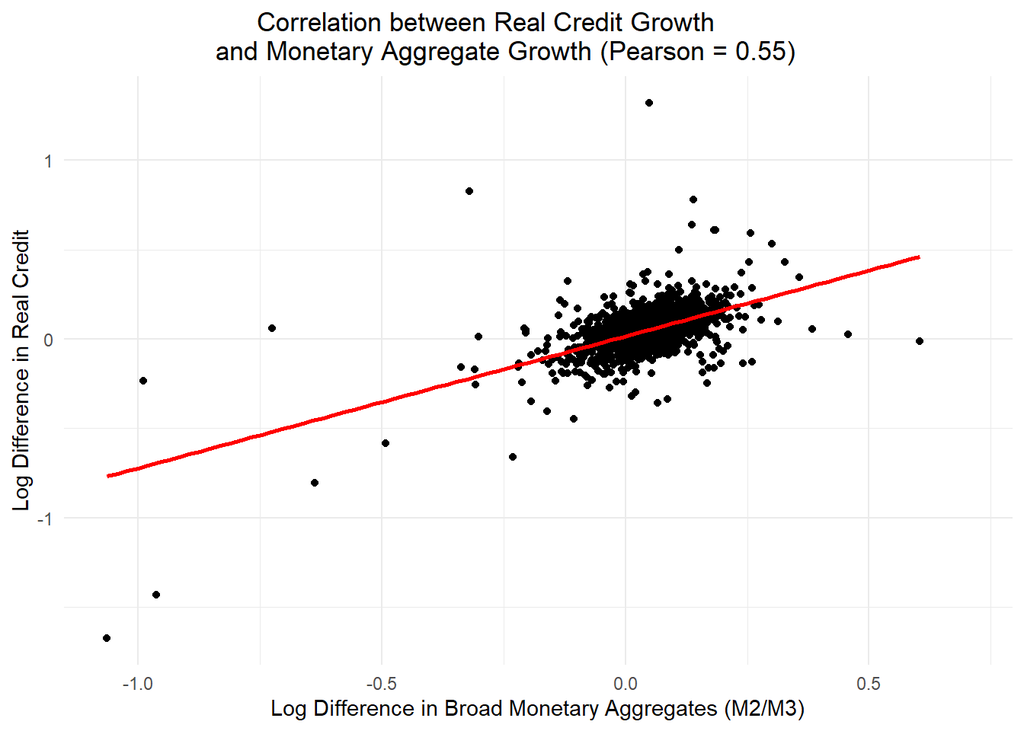

```r
# Compute the correlation coefficient
correlation_coefficient <- cor(jst$ln_diff_money_real, jst$ln_diff_tloans, use = "pairwise.complete.obs")

# Plot visually
jst %>%
  ggplot(aes(x = ln_diff_money_real,
             y = ln_diff_tloans)) +
  geom_point() +
  geom_smooth(method = "lm", se = FALSE, color = "red") +
  labs(title = paste0("Correlation between Real Credit Growth \n and Monetary Aggregate Growth (",
                      "Pearson = ",
                      round(correlation_coefficient, 2), ")"),
       x = "Log Difference in Broad Monetary Aggregates (M2/M3)",
       y = "Log Difference in Real Credit") +
  theme_minimal() +
  theme(plot.title = element_text(hjust = 0.4))
```

#### Public debt as predictor

```r
# Create dependent variable
jst[, diff_debtgdp := debtgdp - shift(debtgdp, 1, type = "lag"), by = c("country")]

# Estimate model
logit_gdp = glm(crisisJST ~
      shift(diff_debtgdp, 1, type = "lag")
      + shift(diff_debtgdp, 2, type = "lag")
      + shift(diff_debtgdp, 3, type = "lag")
      + shift(diff_debtgdp, 4, type = "lag")
      + shift(diff_debtgdp, 5, type = "lag")
      + factor(country)
    ,family = binomial(link = "logit"),
    data = jst)

#Print the results
stargazer(logit_gdp,
          type = "text",
          align = TRUE,
          omit = c("country"),
        dep.var.labels = c("Crisis (JST)"),
        covariate.labels = c("1Y Debt-to-GDP growth - T-1",
                             "1Y Debt-to-GDP growth - T-2",
                             "1Y Debt-to-GDP growth - T-3",
                             "1Y Debt-to-GDP growth - T-4",
                             "1Y Debt-to-GDP growth - T-5"))
```

```
##
## =======================================================
##                                 Dependent variable:
##                             ---------------------------
##                                    Crisis (JST)
## -------------------------------------------------------
## 1Y Debt-to-GDP growth - T-1           -1.254
##                                       (1.978)
##
## 1Y Debt-to-GDP growth - T-2            0.280
##                                       (2.278)
##
## 1Y Debt-to-GDP growth - T-3            1.104
##                                       (2.223)
##
## 1Y Debt-to-GDP growth - T-4          -4.237**
##                                       (1.777)
##
## 1Y Debt-to-GDP growth - T-5           -0.310
##                                       (1.961)
##
## Constant                             -4.280***
##                                       (0.712)
##
## -------------------------------------------------------
## Observations                           2,328
## Log Likelihood                       -323.048
## Akaike Inf. Crit.                     692.096
## =======================================================
## Note:                       *p<0.1; **p<0.05; ***p<0.01
```

### ROC tests - Models using Money and Debt-to-GDP ratio

We split again the data before and after 1984 to obtain our ROC test with the newly created variables.

```r
pre1984 = jst[year <= 1984,]
post1984 = jst[year >= 1984,]
```

#### Money

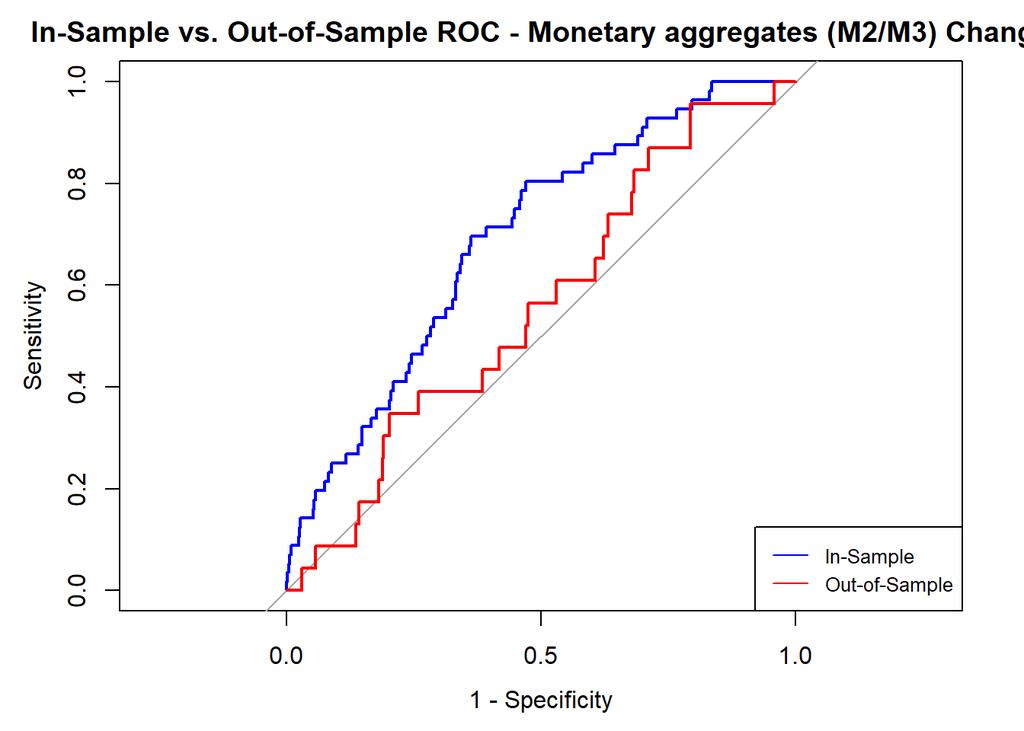

```r
# Estimate model
logit_1984 = glm(crisisJST ~
      shift(ln_diff_money_real, 1, type = "lag")
      + shift(ln_diff_money_real, 2, type = "lag")
      + shift(ln_diff_money_real, 3, type = "lag")
      + shift(ln_diff_money_real, 4, type = "lag")
      + shift(ln_diff_money_real, 5, type = "lag")
      + country
    ,family = binomial(link = "logit"),
    data = pre1984)

# Predict probabilities for training data (in-sample)
pre1984$predicted_prob <- predict(logit_1984, pre1984, type = "response")

# Predict probabilities for testing data (out-of-sample)
post1984$predicted_prob <- predict(logit_1984, post1984, type = "response")

# Compute ROC curve for in-sample data
roc_in_sample <- roc(pre1984$crisisJST, pre1984$predicted_prob)
# Compute ROC curve for out-of-sample data
roc_out_sample <- roc(post1984$crisisJST, post1984$predicted_prob)
# Plot ROC curves
plot(roc_in_sample, col = "blue", main = "In-Sample vs. Out-of-Sample ROC - Monetary aggregates (M2/M3) Change", legacy.axes = TRUE)
plot(roc_out_sample, col = "red", add = TRUE)

# Add legend
legend("bottomright", legend = c("In-Sample", "Out-of-Sample"),
       col = c("blue", "red"), lty = 1, cex = 0.8)
```

```r
# Print AUC values
cat("In-Sample AUC: ", auc(roc_in_sample), "\n")
```

```
## In-Sample AUC:  0.6912874
```

```r
cat("Out-of-Sample AUC: ", auc(roc_out_sample), "\n")
```

```
## Out-of-Sample AUC:  0.5588115
```

#### Debt-to-GDP

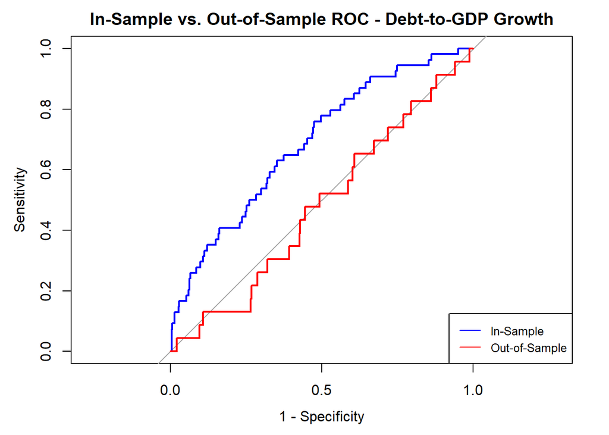

```r
# Estimate model
logit_1984 = glm(crisisJST ~
      shift(diff_debtgdp, 1, type = "lag")
      + shift(diff_debtgdp, 2, type = "lag")
      + shift(diff_debtgdp, 3, type = "lag")
      + shift(diff_debtgdp, 4, type = "lag")
      + shift(diff_debtgdp, 5, type = "lag")
      + country
    ,family = binomial(link = "logit"),
    data = pre1984)

# Predict probabilities for training data (in-sample)
pre1984$predicted_prob <- predict(logit_1984, pre1984, type = "response")

# Predict probabilities for testing data (out-of-sample)
post1984$predicted_prob <- predict(logit_1984, post1984, type = "response")

# Compute ROC curve for in-sample data
roc_in_sample <- roc(pre1984$crisisJST, pre1984$predicted_prob)
# Compute ROC curve for out-of-sample data
roc_out_sample <- roc(post1984$crisisJST, post1984$predicted_prob)
# Plot ROC curves
plot(roc_in_sample, col = "blue", main = "In-Sample vs. Out-of-Sample ROC - Debt-to-GDP Growth", legacy.axes = TRUE)
plot(roc_out_sample, col = "red", add = TRUE)

# Add legend
legend("bottomright", legend = c("In-Sample", "Out-of-Sample"),
       col = c("blue", "red"), lty = 1, cex = 0.8)
```

```r
# Print AUC values
cat("In-Sample AUC: ", auc(roc_in_sample), "\n")
```

```
## In-Sample AUC:  0.6879278
```

```r
cat("Out-of-Sample AUC: ", auc(roc_out_sample), "\n")
```

```
## Out-of-Sample AUC:  0.4794992
```

Analogous considerations apply to the model exploiting the Debt-to-GDP ratio, as it performs worse than both the previous models in sample and it is particularly unsatisfactory out of sample, showing very poor predictive power (Out-of-Sample AUC: 0.4794992).

## Part B - Linear projections

```r
#Merge datasets and adjust shock variables
jst = merge(jst, rec, by = c("year", "iso"))
jst[, log_y := log(rgdpbarro)]

lp_reg = jst[, .(iso, year, log_y, N, `F`)]
lp_reg[, N := ifelse(is.na(N), 0, N)]
lp_reg[, `F` := ifelse(is.na(`F`), 0, `F`)]
```

### Normal Recessions

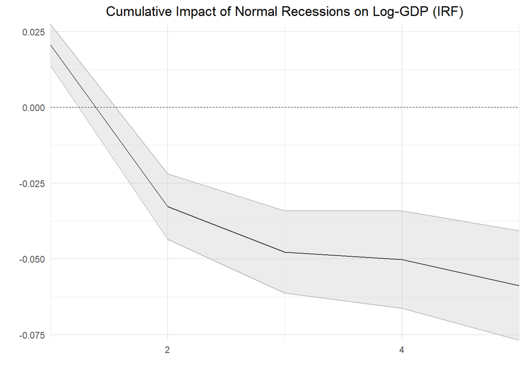

```r
# Estimate model
lp_normal <- lp_lin_panel(
  data_set = lp_reg,
  endog_data = "log_y",      # Dependent variable
  cumul_mult = TRUE,         # Cumulative multipliers
  shock = "N",               # Normal recession
  diff_shock = FALSE,        # No differencing of shocks
  c_fd_exog_data = "F",
  panel_model = "within",    # Fixed effects model
  confint = 1.96,            # 95% confidence interval
  hor = 5                    # Horizons: 1 to 5 years
)

# Plot impulse response functions (IRFs)
# p <- plot(lp_normal)

# Customize the plot
plot(lp_normal) + ggtitle("Cumulative Impact of Normal Recessions on Log-GDP (IRF)") +
  theme_minimal() +  # Use a minimal theme
  theme(plot.title = element_text(hjust = 0.5))
```

### Financial Recessions

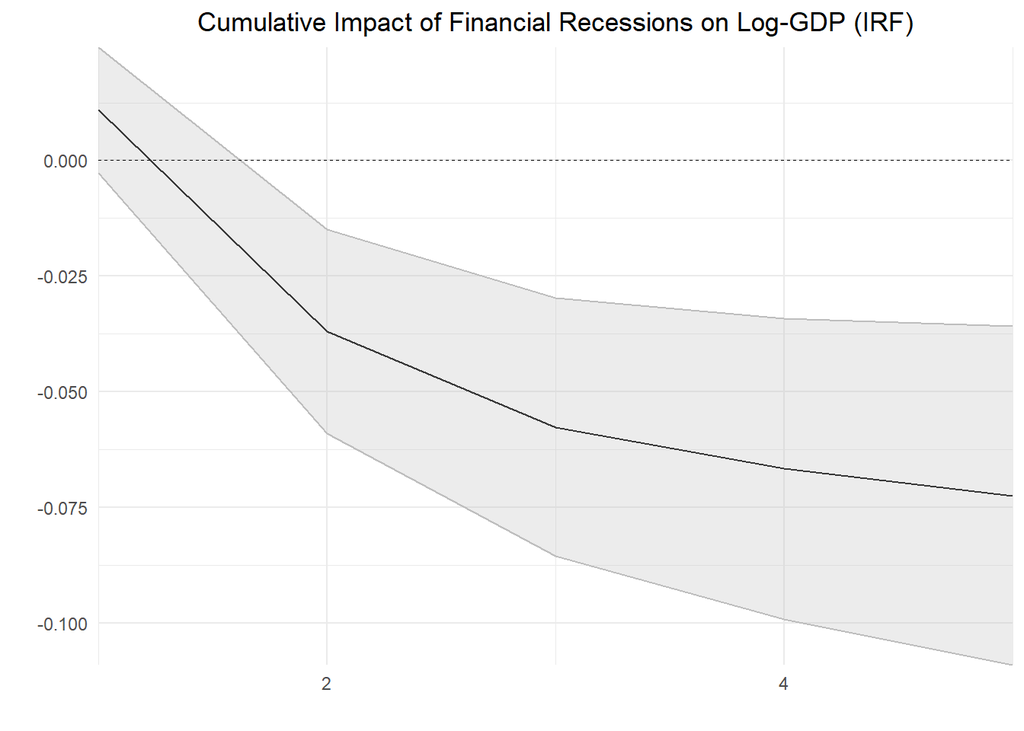

```r
# Estimate model
lp_normal <- lp_lin_panel(
  data_set = lp_reg,
  endog_data = "log_y",      # Dependent variable
  cumul_mult = TRUE,         # Cumulative multipliers
  shock = "F",               # Normal recession
  diff_shock = FALSE,        # No differencing of shocks
  c_fd_exog_data = "N",
  panel_model = "within",    # Fixed effects model
  confint = 1.96,            # 95% confidence interval
  hor = 5                    # Horizons: 1 to 5 years
)

# Plot impulse response functions (IRFs)
p <- plot(lp_normal)

# Customize the plot
p + ggtitle("Cumulative Impact of Financial Recessions on Log-GDP (IRF)") +
  theme_minimal() +  # Use a minimal theme
  theme(plot.title = element_text(hjust = 0.5))
```